# DSO 522: In-Class Workbook 12

Matteo Sesia

November 12, 2024

# Instructions

Your task is to edit this R Markdown notebook to include your solutions, ensuring that it is well-organized and professional in appearance. Answers must be clear and concise. Start by downloading the Rmd file.

**Collaboration Policy.** You are allowed to discuss this workbook with your classmates and work in groups. Despite group discussions, each student must write and submit their own solutions.

**Assistance Policy.** You may ask for clarifications from the instructor and teaching assistant in class. Do not seek help on these workbooks outside of class, as they are intended to be completed during class time.

**Submission Requirements.** Solutions must be submitted on Brightspace as a PDF writeup. Use the ‘Knit to PDF’ feature in RStudio to prepare your PDF document. Ensure that your PDF document looks like the provided PDF version of the workbook, including all code used to obtain the results in proper code blocks. Make sure your PDF writeup includes *your name* in the title (replace my name with yours).

**Grading Criteria.** This workbook is worth 10 points. To achieve a grade of 10, your writeup must correctly answer all questions, be easy to understand, and be formatted correctly.

**Work Timeline.** You are expected to work on this assignment in class, but you may complete it at home within 24 hours. It is due on November 13, 2024, at 9:30 pm. Late submissions will incur a 50% deduction for any initial delay below 24 hours, and an additional 10% deduction for each additional day.

Remember, you will need to use the `fpp3` package to complete this assignment, as shown in the lecture.

```r
suppressMessages(library(fpp3))
```

# Problem 1

The Pharmaceutical Benefit Scheme (PBS) provides a subsidy for many pharmaceutical products sold in Australia, and the expenditure depends on what people purchase during the year.

Consider the `PBS` data which has aggregation structure `ATC1 * Concession * Type`.

For simplicity, we will focus on data with ATC1 equal to A (Alimentary tract and metabolism) or B (Blood and blood forming organs).

We will ignore `ATC2` to speed up the analysis.

1. Produce plots of the aggregated data by `Concession`, `Type` and `ATC1`.
2. Forecast the PBS Scripts data using ETS and SNAIVE models, applied to all but the last three years of data.
3. Reconcile each of the forecasts using the bottom_up approach.
4. Which type of model works best on the test set?
5. Does the reconciliation improve the forecast accuracy?
6. Why doesn’t the reconciliation make any difference to the SNAIVE forecasts?

# Problem 1 Solutions

1. Produce plots of the aggregated data by `Concession`, `Type` and `ATC1`.

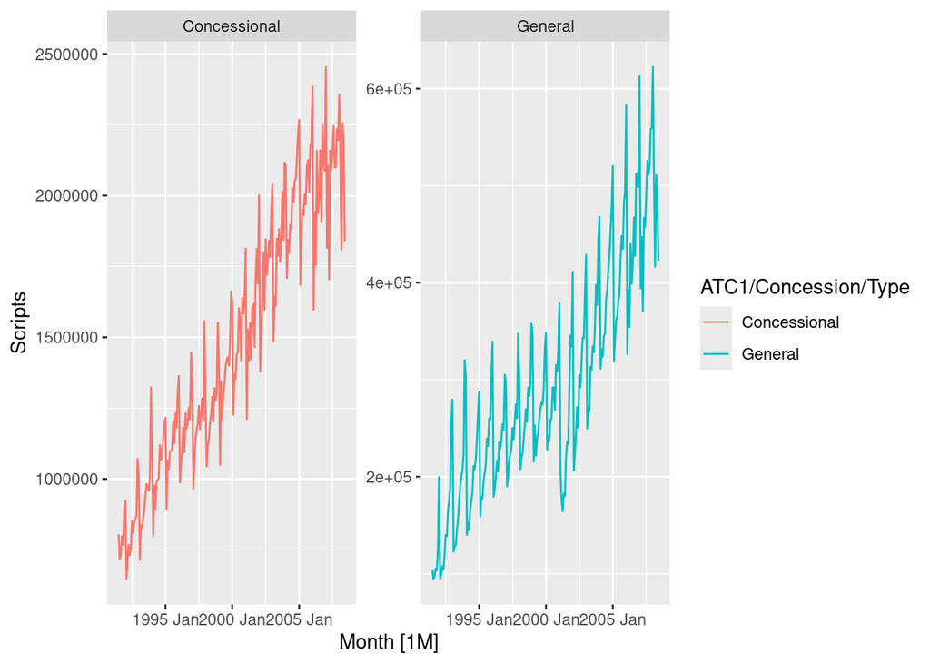

```r
# Fill gaps with 0s
PBS_small <- PBS |>
  filter(ATC1 %in% c("A","B")) |>
  fill_gaps(Scripts=0, .full=TRUE)

# Find series that are only 0s and exclude them.
PBS_small_zeros <- PBS_small |>
  as_tibble() |>
  group_by(ATC1, Concession, Type) |>
  summarise(mas = mean(abs(Scripts))) |>
  filter(mas==0)

PBS_small <- PBS_small |>
  anti_join(PBS_small_zeros)

# Aggregate data
PBSagg <- PBS_small |>
  aggregate_key(ATC1 * Concession * Type, Scripts = sum(Scripts))

PBSagg |>
  filter(!is_aggregated(Concession), is_aggregated(Type), is_aggregated(ATC1)) |>
  autoplot(Scripts, aes(color=Concession)) +
  facet_wrap(Concession~., scales="free")
```

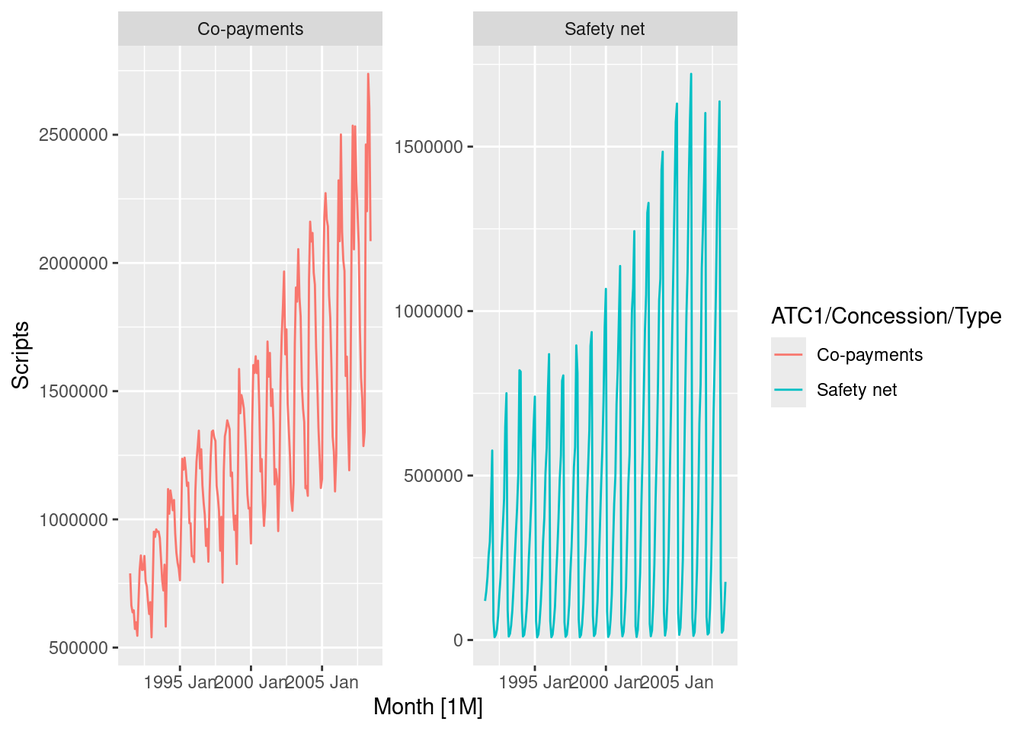

```r
PBSagg |>
  filter(is_aggregated(Concession), !is_aggregated(Type), is_aggregated(ATC1)) |>
  autoplot(Scripts, aes(color=Type)) +
  facet_wrap(Type~., scales="free")
```

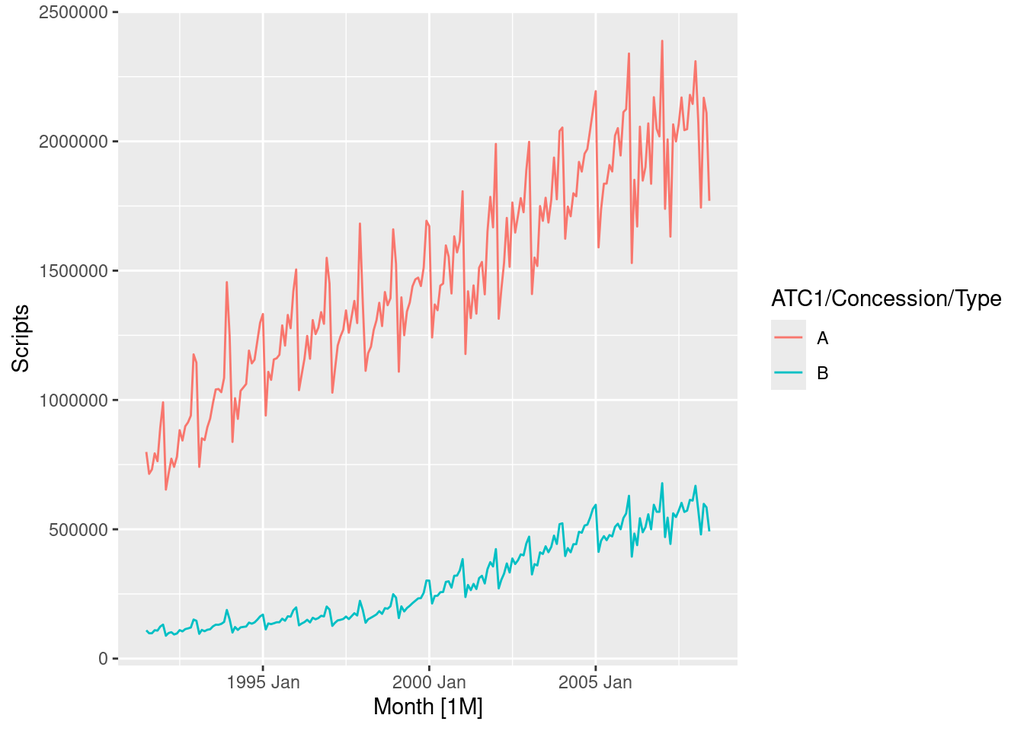

```r
PBSagg |>
  filter(is_aggregated(Concession), is_aggregated(Type), !is_aggregated(ATC1)) |>
  autoplot(Scripts, aes(color=ATC1))
```

```r
PBSfc <- PBSagg |>
  filter(Month < max(Month)-3*12) |>
  model(
    ets = ETS(Scripts),
    snaive = SNAIVE(Scripts)
  ) |>
  reconcile(
    ets2 = bottom_up(ets),
    snaive2 = bottom_up(snaive)
  ) |>
  forecast(h = "3 years")
```

4. Which type of model works best on the test set?

```r
PBSfc |>
  accuracy(PBSagg) |>
  filter(is_aggregated(Concession), is_aggregated(Type), is_aggregated(ATC1)) |>
  select(.model, RMSE, RMSSE)
```

| .model | RMSE | RMSSE |
| --- | --- | --- |
| ets | 248838.7 | 1.622558 |
| ets2 | 228704.2 | 1.491270 |
| snaive | 240174.4 | 1.566062 |
| snaive2 | 240174.4 | 1.566062 |

5. Does the reconciliation improve the forecast accuracy?

The ETS model shows some improvements after reconciliation.

6. Why doesn’t the reconciliation make any difference to the SNAIVE forecasts?

SNAIVE forecasts are already coherent because they are simply equal to the last year of observed data.